# StanとRでベイズ統計モデリング12

UPDATE: 2024-01-21 19:54:43.712713

# はじめに

このノートは「StanとRでベイズ統計モデリング」の内容を写経することで、ベイズ統計への理解を深めていくために作成している。

- [StanとRでベイズ統計モデリング](https://www.kyoritsu-pub.co.jp/bookdetail/9784320112421)
- [StanとRでベイズ統計モデリング サポートページ](https://github.com/MatsuuraKentaro/RStanBook)

基本的には気になった部分を写経しながら、ところどころ自分用の補足をメモすることで、「StanとRでベイズ統計モデリング」を読み進めるための自分用の補足資料になることを目指す。私の解釈がおかしく、メモが誤っている場合があるので注意。

今回は第10章「収束しない場合の対処法」のチャプターを写経していく。

## 10.1.4 多項ロジスティック回帰

ここでは、購入された商品カテゴリと年齢、性別、年収の関係を多項ロジスティック回帰モデルを利用して分析する。この過程で収束しない場合の対処方法を扱う。使用するデータは下記の通り。

```r
library(dplyr)
library(rstan)
library(ggplot2)

options(max.print = 999999)
rstan_options(auto_write=TRUE)
options(mc.cores=parallel::detectCores())

d <- read.csv('https://raw.githubusercontent.com/MatsuuraKentaro/RStanBook/master/chap10/input/data-category.txt')
d$Age <- d$Age/100
d$Income <- d$Income/1000
X <- cbind(1, d[,-ncol(d)])
data <- list(N = nrow(d), D = ncol(X), K = 6, X = X, Y = d$Y)
data
```

```
## $N
## [1] 300
##
## $D
## [1] 4
##
## $K
## [1] 6
##
## $X
##     1  Age Sex Income
## 1   1 0.18   1  0.472
## 2   1 0.18   0  0.468
## 3   1 0.18   1  0.451
## 4   1 0.18   1  0.441
```

[output cut: 307 more lines]

ここでのモデルは、どのような年齢、性別、年収の人が、どのカテゴリーの商品を選びやすいかを知ることで、多項ロジスティック回帰モデルを利用する。各カテゴリーを選択確率$\overrightarrow{\theta}$は説明変数の線形結合によって決まると考える。

モデル10-2

$$\begin{eqnarray}
\overrightarrow{\mu[n]} &\sim& \overrightarrow{\beta_{1}} +
\overrightarrow{\beta_{2}}Age[n] + \overrightarrow{\beta_{3}}Sex[n] +
\overrightarrow{\beta_{4}}Income[n] \\
\overrightarrow{\theta[n]} &=& softmax(\overrightarrow{\mu[n]})
\\
Y[n] &=& Categorical(\overrightarrow{\theta[n]}) \\
\\
\overrightarrow{\theta} &=& softmax(\overrightarrow{\mu}) =
\left( \frac{exp(\mu_{1})}{\sum_{k=1}^{K} exp(\mu_{k})}...
\frac{exp(\mu_{k})}{\sum_{k=1}^{K}
exp(\mu_{k})}\right)^{T}
\end{eqnarray}$$

$\overrightarrow{\beta_{1}},\overrightarrow{\beta_{2}},\overrightarrow{\beta_{3}},\overrightarrow{\beta_{4}}$は長さ$K$のベクトルであり、$\overrightarrow{\beta_{1}},\overrightarrow{\beta_{2}},\overrightarrow{\beta_{3}},\overrightarrow{\beta_{4}}$をデータから推定する。

softmax関数はこのままでは識別不可能なので、少し工夫する必要がある。そもそも識別可能とは、$\theta_{0}^{*}$における事後確率を$p(\theta = \theta_{0}|Y)$とするとき、$p(\theta = \theta_{0}|Y)=p(\theta = \theta_{0}^{*}|Y)$となる別の$\theta_{0}^{*}$が存在しない時、パラメタ$\theta$識別可能となる。参考書には$\mu$に定数を加えても、元に戻る例が記載されているが、これの意味は下記の通り。

```r
softmax <- function(x){
  exp(x)/sum(exp(x))
}

list(
  softmax(c(1,2,3)),
  softmax(c(1,2,3)+1)
)
```

```
## [[1]]
## [1] 0.09003057 0.24472847 0.66524096
##
## [[2]]
## [1] 0.09003057 0.24472847 0.66524096
```

現状のsoftmax関数では、識別可能な状態ではないので、カテゴリ1を選ぶ強さを0に固定する。こうすることで、残りのカテゴリの「強さ」はカテゴリ1との比較できまる。実装では$\mu_{1}=0$とすることで、相対的な順序関係は保たれたまま、識別可能となる。

```r
softmax(c(0,1,-1))
```

```
## [1] 0.24472847 0.66524096 0.09003057
```

モデルは下記の通りである。

```
data {
  int N;
  int D;
  int K;
  matrix[N,D] X;
  int<lower=1, upper=K> Y[N];
}

transformed data {
  vector[D] Zeros;
  Zeros = rep_vector(0,D);
}

parameters {
  matrix[D,K-1] b_raw;
}

transformed parameters {
  matrix[D,K] b;
  matrix[N,K] mu;
  b = append_col(Zeros, b_raw);
  mu = X*b;
}

model {
  for (n in 1:N){
    Y[n] ~ categorical(softmax(mu[n,]'));
    }
}
```

下記の部分が気になったので、深掘りしておく。

```
transformed parameters {
  matrix[D,K] b;
  matrix[N,K] mu;
  // Xは(300×4)、bは(4×6)よりmu(300×6)となる
  b = append_col(Zeros, b_raw);
  mu = X*b;
}

model {
  for (n in 1:N){
  // (')転置記号があるので
                       Y[n] ~ categorical(softmax(mu[n,]'));
    }
}
```

ここでは、`stan_model()`関数で最初にコンパイルしておいてから、

```r
model102 <- stan_model('note_ahirubayes12-102.stan')
```

`sampling()`関数でサンプリングする。

```r
fit <- sampling(object = model102, data = data, seed = 1989)
```

推定結果は下記の通り。

```r
print(fit, prob = c(0.025, 0.5, 0.975), pars = c('b_raw'), digits_summary = 1)
```

```
## Inference for Stan model: anon_model.
## 4 chains, each with iter=2000; warmup=1000; thin=1;
## post-warmup draws per chain=1000, total post-warmup draws=4000.
##
##            mean se_mean  sd  2.5%  50% 97.5% n_eff Rhat
## b_raw[1,1] -0.1     0.0 1.1  -2.3 -0.1   1.9  2008    1
## b_raw[1,2]  0.2     0.0 1.8  -3.4  0.2   3.8  2097    1
## b_raw[1,3] -1.0     0.0 1.2  -3.3 -1.0   1.3  1922    1
## b_raw[1,4]  2.3     0.0 2.6  -2.9  2.3   7.3  2878    1
## b_raw[1,5]  0.6     0.0 1.2  -1.7  0.6   2.8  1953    1
## b_raw[2,1] -1.5     0.0 1.5  -4.4 -1.5   1.4  2979    1
## b_raw[2,2] -4.7     0.0 2.8 -10.5 -4.7   0.8  3278    1
## b_raw[2,3] -2.3     0.0 1.7  -5.7 -2.3   1.1  2776    1
## b_raw[2,4] -9.5     0.1 4.5 -19.3 -9.3  -1.4  4582    1
## b_raw[2,5] -3.2     0.0 1.8  -6.8 -3.2   0.1  3190    1
## b_raw[3,1] -1.2     0.0 0.4  -1.9 -1.2  -0.5  3104    1
## b_raw[3,2] -3.3     0.0 0.9  -5.3 -3.3  -1.8  4657    1
## b_raw[3,3] -1.9     0.0 0.4  -2.6 -1.9  -1.1  3344    1
## b_raw[3,4]  0.0     0.0 1.0  -1.7  0.0   2.0  4387    1
## b_raw[3,5] -2.0     0.0 0.4  -2.7 -2.0  -1.2  3461    1
## b_raw[4,1]  2.9     0.0 1.6  -0.3  2.8   6.2  2070    1
## b_raw[4,2]  2.1     0.1 2.7  -3.3  2.2   7.5  2478    1
## b_raw[4,3]  4.7     0.0 1.8   1.2  4.6   8.3  2023    1
## b_raw[4,4] -3.4     0.1 4.4 -12.5 -3.2   4.8  3415    1
## b_raw[4,5]  2.6     0.0 1.8  -0.8  2.6   6.2  2025    1
##
## Samples were drawn using NUTS(diag_e) at Sun Jan 21 19:55:10 2024.
## For each parameter, n_eff is a crude measure of effective sample size,
## and Rhat is the potential scale reduction factor on split chains (at
## convergence, Rhat=1).
```

## 10.1.5 ウサギとカメ

収束に関わる識別可能性について、ウサギとカメの例題を通じて理解を深める。ウサギとカメのマラソンの勝敗結果(ウサギの26勝4敗、カメの4勝26敗)からウサギとカメの「強さ」を推定する。

インデックスの1がカメで、インデックスの2がウサギである。敗者の列と勝者の列があって、勝敗結果によって各インデックスが記録される。1レース目では、`Loser`のインデックスが1なので、カメが敗者である。

```r
d <- read.csv('https://raw.githubusercontent.com/MatsuuraKentaro/RStanBook/master/chap10/input/data-usagitokame.txt')
data <- list(N = 2, G = nrow(d), LW = d)
data
```

```
## $N
## [1] 2
##
## $G
## [1] 30
##
## $LW
##    Loser Winner
## 1      1      2
## 2      1      2
## 3      2      1
## 4      1      2
## 5      1      2
## 6      1      2
## 7      1      2
```

[output cut: 23 more lines]

モデルのメカニズムを考える。カメの強さ$\mu[1]$、ウサギの強さ$\mu[2]$とする。各レースごとに発揮できた力をパフォーマンスと考える。カメのパフォーマンスは平均$\mu[1]$、標準偏差$\sigma[1]$の正規分布から生成されると考える。$\sigma[1]$はカメのパフォーマンスのムラの大きさであり、ムラがあまりなければパフォーマンスはだいたい同じになるが、ムラが大きいとパフォーマンスは毎回大きく異なる。ウサギについても同様である。ここではデータが少ないので、勝負ムラは$\sigma[1]=\sigma[2]=\sigma$とする。

尤度を考える際には、パフォーマンスの差だけが勝敗に関係し、強さを平行移動しても同じ尤度になるため識別不可能になる。そこで片方の強さを$\mu[1]=0$に固定する。また、$(\mu[2]|\sigma)=(3,2)$は$(\mu[2]|\sigma)=(6,4)$は同じ尤度になるので、$\sigma=1$に固定する。

モデル10-3

$$\begin{eqnarray}
performance[g,1] &\sim& Normal(\mu[Loser[g]],1)\\
performance[g,2] &\sim& Normal(\mu[Winner[g]],1) \\
performance[g,1] &\lt& performance[g,2] \\
\mu[1] &=& 0
\end{eqnarray}$$

モデルは下記の通り。`ordered[2] performance[G]`としてパフォーマンスの制約を表現している。order型は順序付きベクトルと呼ばれ、長さ$N$の要素が$x_{1} \lt x_{2} \lt...\lt x_{N}$を満たす。雑誌ランキングなど、順序つきのデータがあった場合に、各雑誌の真の面白さを大小関係があるパラメタと考え、order型で宣言して推定する。

```
data {
  int N;  // num of players
  int G;  // num of games
  int<lower=1, upper=N> LW[G,2];  // loser and winner of each game
}

parameters {
  ordered[2] performance[G];
  real b;
}

transformed parameters {
  real mu[N];
  mu[1] = 0;
  mu[2] = b;
}

model {
  for (g in 1:G){
    for (i in 1:2){
      performance[g,i] ~ normal(mu[LW[g,i]], 1);
    }
  }
}
```

下記の部分を深掘りしておく。

```
transformed parameters {
  real mu[N];
  mu[1] = 0;
  mu[2] = b;
  // mu = (0, b)という関係になる
}

model {
  for (g in 1:G){
    for (i in 1:2){
      performance[g,i] ~ normal(mu[LW[g,i]], 1);
    }
  }
}
// g=1,i=1
// performance[1,1] ~ normal(mu[LW[1,1]], 1);
// performance[1,1] ~ normal(mu[1], 1);
// performance[1,1] ~ normal(0, 1);

// g=1,i=2
// performance[1,2] ~ normal(mu[LW[1,2]], 1);
// performance[1,2] ~ normal(mu[2], 1);
// performance[1,2] ~ normal(b, 1);
```

ここでは、`stan_model()`関数で最初にコンパイルしておいてから、

```r
model103 <- stan_model('note_ahirubayes12-103.stan')
```

`sampling()`関数でサンプリングする。

```r
fit <- sampling(object = model103, data = data, seed = 1989)
```

推定結果は下記の通り。カメの強さを$\mu[0]=0$とした場合、ウサギの強さ$\mu[1]$は1.6[0.8〜2.4]と推定された。

```r
print(fit, prob = c(0.025, 0.5, 0.975), digits_summary = 2)
```

```
## Inference for Stan model: anon_model.
## 4 chains, each with iter=2000; warmup=1000; thin=1;
## post-warmup draws per chain=1000, total post-warmup draws=4000.
##
##                     mean se_mean   sd   2.5%    50%  97.5% n_eff Rhat
## performance[1,1]   -0.18    0.01 0.94  -2.07  -0.15   1.62  5002    1
## performance[1,2]    1.78    0.02 0.99  -0.08   1.73   3.88  3661    1
## performance[2,1]   -0.18    0.01 0.93  -2.08  -0.16   1.54  5683    1
## performance[2,2]    1.78    0.02 0.97  -0.09   1.75   3.77  3400    1
## performance[3,1]    0.43    0.01 0.81  -1.21   0.44   1.96  5582    1
## performance[3,2]    1.16    0.01 0.79  -0.36   1.16   2.74  4824    1
## performance[4,1]   -0.17    0.01 0.91  -1.95  -0.15   1.55  4760    1
## performance[4,2]    1.76    0.02 1.00  -0.09   1.71   3.81  3395    1
## performance[5,1]   -0.19    0.01 0.92  -2.05  -0.19   1.54  5165    1
## performance[5,2]    1.75    0.02 0.96  -0.04   1.74   3.71  3610    1
## performance[6,1]   -0.17    0.01 0.89  -1.93  -0.14   1.49  6068    1
## performance[6,2]    1.79    0.02 0.97   0.00   1.73   3.75  4040    1
## performance[7,1]   -0.19    0.01 0.93  -2.18  -0.17   1.52  6119    1
## performance[7,2]    1.79    0.02 0.98  -0.02   1.77   3.82  3677    1
## performance[8,1]   -0.19    0.01 0.91  -2.02  -0.17   1.54  6067    1
## performance[8,2]    1.77    0.02 0.98  -0.02   1.73   3.78  3614    1
## performance[9,1]   -0.17    0.01 0.90  -1.99  -0.15   1.58  5156    1
## performance[9,2]    1.76    0.02 0.97  -0.05   1.72   3.76  3905    1
## performance[10,1]  -0.17    0.01 0.93  -2.04  -0.16   1.63  5382    1
## performance[10,2]   1.77    0.02 1.00  -0.10   1.75   3.86  3100    1
## performance[11,1]  -0.16    0.01 0.93  -2.05  -0.15   1.60  4882    1
## performance[11,2]   1.77    0.02 0.99  -0.05   1.76   3.74  3599    1
## performance[12,1]  -0.18    0.01 0.91  -2.04  -0.16   1.53  4513    1
## performance[12,2]   1.79    0.02 0.97   0.02   1.76   3.76  3416    1
## performance[13,1]   0.44    0.01 0.82  -1.19   0.44   2.02  5676    1
## performance[13,2]   1.15    0.01 0.80  -0.38   1.15   2.75  4961    1
## performance[14,1]  -0.20    0.01 0.93  -2.09  -0.16   1.54  6024    1
## performance[14,2]   1.77    0.02 0.96  -0.09   1.76   3.76  3434    1
## performance[15,1]  -0.18    0.01 0.92  -1.97  -0.17   1.56  4703    1
## performance[15,2]   1.76    0.02 0.98  -0.05   1.73   3.75  3374    1
## performance[16,1]   0.45    0.01 0.81  -1.22   0.46   1.99  5476    1
## performance[16,2]   1.16    0.01 0.80  -0.40   1.16   2.79  4767    1
## performance[17,1]  -0.20    0.01 0.93  -2.04  -0.19   1.56  6043    1
## performance[17,2]   1.79    0.02 0.97  -0.09   1.77   3.75  3524    1
## performance[18,1]  -0.19    0.01 0.91  -2.06  -0.16   1.49  5767    1
```

[output cut: 19 more lines]

```
## performance[28,1]  -0.18    0.01 0.93  -2.12  -0.16   1.52  5271    1
## performance[28,2]   1.78    0.02 0.96  -0.06   1.77   3.75  3277    1
## performance[29,1]  -0.16    0.01 0.90  -1.97  -0.16   1.57  5432    1
## performance[29,2]   1.75    0.02 0.99  -0.07   1.72   3.82  3693    1
## performance[30,1]  -0.18    0.01 0.91  -1.98  -0.17   1.51  5441    1
## performance[30,2]   1.79    0.02 0.98  -0.03   1.77   3.76  3351    1
## b                   1.59    0.01 0.41   0.81   1.59   2.42  2210    1
## mu[1]               0.00     NaN 0.00   0.00   0.00   0.00   NaN  NaN
## mu[2]               1.59    0.01 0.41   0.81   1.59   2.42  2210    1
## lp__              -23.97    0.20 6.69 -37.61 -23.68 -11.50  1074    1
##
## Samples were drawn using NUTS(diag_e) at Sun Jan 21 19:55:20 2024.
## For each parameter, n_eff is a crude measure of effective sample size,
## and Rhat is the potential scale reduction factor on split chains (at
## convergence, Rhat=1).
```

試合結果と各試合のパフォーマンスの対応をメモしておく。カメが負け、ウサギが勝ちの場合、パフォーマンスの関係は`performance[g,2]`が大きくなっている。3試合目はカメが勝ち、ウサギが負けの場合であるが、パフォーマンスの関係は変わっていないもの、

```
   Loser Winner
1      1      2 <- カメが負け、ウサギが勝ち
2      1      2 <- カメが負け、ウサギが勝ち
3      2      1 <- ウサギが負け、カメが勝ち

// g=1,i=1
// performance[1,1] ~ normal(mu[LW[1,1]], 1);
// performance[1,1] ~ normal(mu[1], 1);
// performance[1,1] ~ normal(0, 1);

// g=1,i=2
// performance[1,2] ~ normal(mu[LW[1,2]], 1);
// performance[1,2] ~ normal(mu[2], 1);
// performance[1,2] ~ normal(b, 1);
                    mean   sd   2.5%    50%  97.5%
performance[1,1]   -0.18 0.94  -2.07  -0.15   1.62 <- Loser: カメ
performance[1,2]    1.78 0.99  -0.08   1.73   3.88 <- Winner: ウサギ

// g=2,i=1
// performance[2,1] ~ normal(mu[LW[1,2]], 1);
// performance[2,1] ~ normal(mu[1], 1);
// performance[2,1] ~ normal(0, 1);

// g=2,i=2
// performance[2,2] ~ normal(mu[LW[2,2]], 1);
// performance[2,2] ~ normal(mu[2], 1);
// performance[2,2] ~ normal(b, 1);
                    mean   sd   2.5%    50%  97.5%
performance[2,1]   -0.18 0.93  -2.08  -0.16   1.54 <- Loser: カメ
performance[2,2]    1.78 0.97  -0.09   1.75   3.77 <- Winner: ウサギ

// g=3,i=1
// performance[3,1] ~ normal(mu[LW[3,1]], 1);
// performance[3,1] ~ normal(mu[2], 1);
// performance[3,1] ~ normal(b, 1);

// g=3,i=2
// performance[3,2] ~ normal(mu[LW[3,2]], 1);
// performance[3,2] ~ normal(mu[1], 1);
// performance[3,2] ~ normal(0, 1);
                    mean   sd   2.5%    50%  97.5%
performance[3,1]    0.43 0.81  -1.21   0.44   1.96 <- Loser: ウサギ
performance[3,2]    1.16 0.79  -0.36   1.16   2.74 <- Winner: カメ
```

今回のモデルのメカニズムは少しわかりにくいので、データ生成を通じて、どのようなメカニズムを想定しているのか確認しておく。

```r
set.seed(123)

G <- 30
mu_pf <- c(0, 1.5)
pf <- sapply(mu_pf, function(mu) rnorm(G, mean = mu, sd = 1))
colnames(pf) <- c('mu=0,sd=1', 'mu=1.5,sd=1')
```

`sapply()`関数の部分がわかりにくいかもしれないので、小さい例を載せておく。平均`mu(0, 1.5)`、標準偏差1をもつ分布から、30レース分の乱数を生成している。

```r
pf
```

```
##         mu=0,sd=1 mu=1.5,sd=1
##  [1,] -0.56047565   1.9264642
##  [2,] -0.23017749   1.2049285
##  [3,]  1.55870831   2.3951257
##  [4,]  0.07050839   2.3781335
##  [5,]  0.12928774   2.3215811
##  [6,]  1.71506499   2.1886403
##  [7,]  0.46091621   2.0539177
##  [8,] -1.26506123   1.4380883
##  [9,] -0.68685285   1.1940373
## [10,] -0.44566197   1.1195290
## [11,]  1.22408180   0.8052930
## [12,]  0.35981383   1.2920827
## [13,]  0.40077145   0.2346036
## [14,]  0.11068272   3.6689560
```

[output cut: 16 more lines]

このデータに対して、行方向を基準に、大小を比較して、大きい方は2、小さい方は1としている。27レース目の`0.83778704 > -0.0487528`という関係なので、`2, 1`と順序が付与される。

```r
t(apply(pf, 1, order))
```

```
##       [,1] [,2]
##  [1,]    1    2
##  [2,]    1    2
##  [3,]    1    2
##  [4,]    1    2
##  [5,]    1    2
##  [6,]    1    2
##  [7,]    1    2
##  [8,]    1    2
##  [9,]    1    2
## [10,]    1    2
## [11,]    2    1
## [12,]    1    2
## [13,]    2    1
## [14,]    1    2
```

[output cut: 16 more lines]

このような想定の元、レースの勝敗がきまる。

```r
d <- data.frame(t(apply(pf, 1, order)))
colnames(d) <- c('Loser', 'Winner')
tbl <- table(d$Winner)
tbl
```

```
##
##  1  2
##  4 26
```

例えば、カメの勝負ムラが大きく`sd=5`くらいあったとすると、30レース中9回はウサギに勝つ可能性がある。

```r
set.seed(1989)
pf_mura <- matrix(
  rnorm(60, mean = c(0, 1.5), sd = c(5, 1)),
  ncol = 2,
  byrow = TRUE
)
d_mura <- data.frame(t(apply(pf_mura, 1, order)))
colnames(d_mura) <- c('Loser', 'Winner')
table(d_mura$Winner)
```

```
##
##  1  2
##  9 21
```

## 10.2.2 正の値を持つパラメタ

正の値を持つパラメタの事前分布の第一候補は一様分布$U(0,1000$である。ただ、場合によっては、大きな値を取ってしまうことがあるので、ある程度は制限をかけたい。その際に利用されるのが弱情報事前分布。

共役関係から、かつては標準偏差の事前分布は逆ガンマ分布を利用すること多かったが、逆ガンマ分布のパラメタは値によって、形状が大きく変化するため、原点0付近での確率密度が大きく異なる。下記は$InvGamma(0.1,0.1)$を可視化したもの。

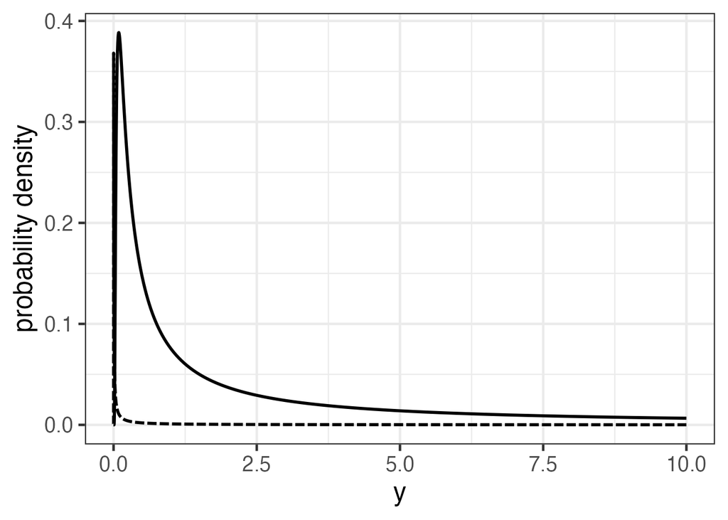

```r
library(MCMCpack)
x <- c(seq(1e-10, 0.0005, length = 100), seq(0.0005, 0.005, length = 100), seq(0.005, 0.02, length = 100), seq(0.02, 0.5, length = 100), seq(0.5, 3, length = 100), seq(3, 10, length = 100))
p1 <- dinvgamma(x, shape = 0.001, scale = 0.001)
p2 <- dinvgamma(x, shape = 0.1, scale = 0.1)
d <- data.frame(x = x, y1 = p1, y2 = p2)

ggplot() +
  theme_bw(base_size = 18) +
  geom_line(data = d, aes(x = x, y = y1), color = 'black', linewidth = 1, linetype = '31') +
  geom_line(data = d, aes(x = x, y = y2), color = 'black', linewidth = 1) +
  labs(x = 'y', y = 'probability density')
```

下記は$InvGamma(0.001,0.001)$を可視化したもの。このような形状の違いによる問題は対数正規分布でも起こりうる。

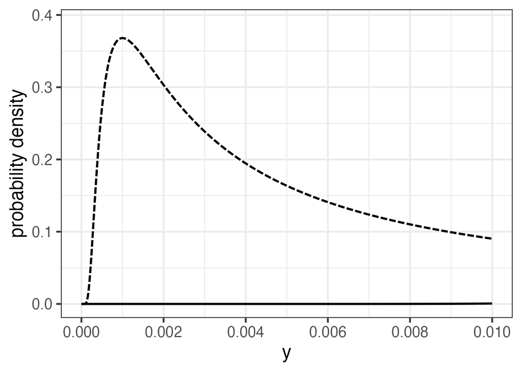

```r
ggplot() +
  theme_bw(base_size = 18) +
  geom_line(data = d, aes(x = x, y = y1), color = 'black', linewidth = 1, linetype = '31') +
  geom_line(data = d, aes(x = x, y = y2), color = 'black', linewidth = 1) +
  labs(x = 'y', y = 'probability density') +
  scale_x_continuous(breaks = seq(from = 0, to = 0.01, by = 0.002), limits = c(0, 0.01))
```

これを避ける方法として、半t分布や半正規分布を利用する方法がある。半t分布は0近くの確率密度が十分あるので、逆ガンマ分布のような欠点が修正される。点線が半正規分布のグラフ。

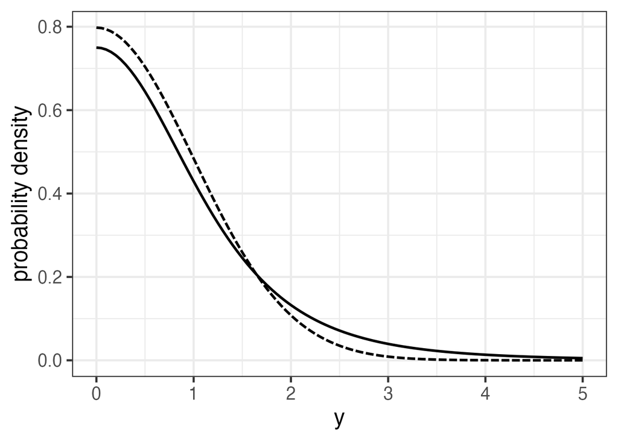

```r
x <- seq(0, 5, length=101)
p1 <- 2*dt(x, df=4)
p2 <- 2*dnorm(x, mean=0, sd=1)
d <- data.frame(x=x, y1=p1, y2=p2)

ggplot() +
  theme_bw(base_size=18) +
  geom_line(data=d, aes(x=x, y=y1), linewidth=1) +
  geom_line(data=d, aes(x=x, y=y2), linewidth=1, linetype='31') +
  labs(x='y', y='probability density')
```

他にも指数分布、ガンマ分布などを利用されるが、可視化して一番妥当な分布を利用することが望ましい。ガンマ分布であれば、$shape,rate$ともに固定値を与えて使うか、いずれか、または、両方が確率分布に従うと考えて、$Gamma(shape,rate)$として利用する。例えば、パラメタが平均1、標準偏差0.32の正規分布で近似できそうであれば、$Gamma(10,10)$を利用する方法もある。

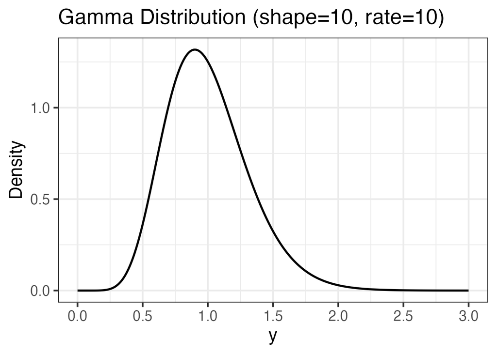

```r
data.frame(
  x = seq(0, 3, by = 0.01),
  y = dgamma(seq(0, 3, by = 0.01), shape = 10, rate = 10)
  ) %>%
  ggplot(data = ., aes(x=x, y=y)) +
  theme_bw(base_size = 18) +
  geom_line(linewidth=1) +
  scale_x_continuous(breaks = seq(0, 5, 0.5)) +
  labs(title = "Gamma Distribution (shape=10, rate=10)", x = "y", y = "Density")
```

ガンマ分布の例として、プロ棋士の勝敗データから、各騎士の強さと勝負ムラを推定する。1試合の勝敗ごとに点をやり取りするレーティングによって強さが数値化されている。下記が参考になる。

- [将棋連盟 棋士別成績一覧（レーティング）](http://kishibetsu.com/rating.html)

レーティングは「初期値から落ち着くまでに適正な評価が難しい」「評価のタイミングに依存する」「インフレしやすい」などの問題があるが、その欠点をベイズで克服する。

データは下記の1行1試合の形式で記録されている。1行目であれば、`22番`と`83番`が試合をして、買ったのは`83番`という形で記録されていると思われる。2行目であれば、`39番`と`27番`が試合をして、`39番`が負け、`27番`が勝ち。

```r
d <- read.csv('https://raw.githubusercontent.com/MatsuuraKentaro/RStanBook/master/chap10/input/data-shogi-player.txt')
## 時間がかかるのでサイズを小さくする
d <- d[1:500,]
head(d)
```

```
##   Loser Winner
## 1    22     83
## 2    39     27
## 3    47    105
## 4     1      7
## 5    45     81
## 6    19     77
```

モデルのメカニズムを考える。ウサギとカメのモデルとあまり変わらないが、各騎士の強さを$\mu[n]$、勝負ムラを$\sigma[n]$として、1回の勝負で発揮する力は、平均$\mu[n]$、標準偏差$\sigma[n]$の正規分布から生成されると考える。勝敗はそのパフォーマンスの大小で決まる。

問題はウサギとカメのときのように、いずれかを0に固定するということができない。プレイヤーは166人おり、すべての棋士と対戦している棋士がいない。そのため、そのような棋士を基準にする方法はとれない。その代わりに、階層モデルを適用することで「各騎士の強さは$\mu[n]$は特定の分布に従う」という仮定をたてる。つまり、各騎士の強さ$\mu[n]$は平均0、標準偏差$\sigma_{\mu}$に従うと考える。そして、勝負ムラ$\sigma[n]$には弱情報事前分布(ガンマ分布(10,10))を利用する。勝負ムラの大きさは1前後に固定され、パフォーマンスのスケールが決まる。

メカニズムに関して、[こちら](https://qiita.com/sk_bono36/items/c6ce9e27d4e655a52e62)のQiitaの記事でわかりやすく説明されている図があったのでお借りする。

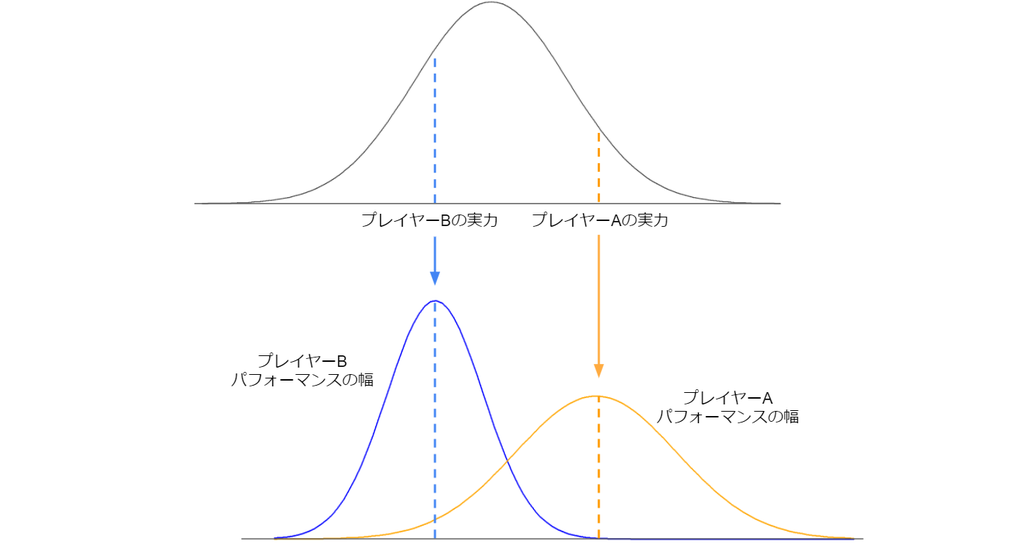

モデル10-4

$$\begin{eqnarray}
performance[g,1] &\sim&
Normal(\color{red}{\mu[}Loser[g]\color{red}{]},\color{blue}{\sigma[}Loser[g]\color{blue}{]})\\
performance[g,2] &\sim&
Normal(\color{red}{\mu[}Winner[g]\color{red}{]},\color{blue}{\sigma[}Winner[g]\color{blue}{]})\\
performance[g,1] &\lt& performance[g,2] \\
\color{red}{\mu[n]} &\sim& Normal(0, \sigma_{\mu}) \\
\color{blue}{\sigma[n]} &\sim& Gamma(10, 10) \\
\end{eqnarray}$$

モデルは下記の通り。

```
data {
  int N;  // num of players
  int G;  // num of games
  int<lower=1, upper=N> LW[G,2];  // loser and winner of each game
}

parameters {
  ordered[2] performance[G];
  vector[N] mu;
  real<lower=0> s_mu;
  vector<lower=0>[N] s_pf;
}

model {
  mu ~ normal(0, s_mu);
  s_pf ~ gamma(10, 10);

  for (g in 1:G){
    for (i in 1:2){
      performance[g,i] ~ normal(mu[LW[g,i]], s_pf[LW[g,i]]);
    }
  }
}
```

この部分の動きを確認しておく。

```
model {
  mu ~ normal(0, s_mu);
  s_pf ~ gamma(10, 10);

  for (g in 1:G){
    for (i in 1:2){
      performance[g,i] ~ normal(mu[LW[g,i]], s_pf[LW[g,i]]);
    }
  }
}

// ここでは試合数を減らしている
// G=500, N=166
// g=1, i=1, Loser
// performance[1,1] ~ normal(mu[LW[1,1]], s_pf[LW[1,1]]);
// performance[1,1] ~ normal(mu[22], s_pf[22]);
// g=1, i=2, Wwinner
// performance[1,2] ~ normal(mu[LW[1,2]], s_pf[LW[1,2]]);
// performance[1,2] ~ normal(mu[83], s_pf[83]);
// ...
// g=500, i=1, Loser
// performance[500,1] ~ normal(mu[LW[500,1]], s_pf[LW[500,1]]);
// performance[500,1] ~ normal(mu[113], s_pf[113]);
// g=500, i=2, Winner
// performance[500,2] ~ normal(mu[LW[500,2]], s_pf[LW[500,2]]);
// performance[500,2] ~ normal(mu[4], s_pf[4]);
```

ここでは、`stan_model()`関数で最初にコンパイルしておいてから、

```r
model104 <- stan_model('note_ahirubayes12-104.stan')
```

`sampling()`関数でサンプリングする。

```r
N <- max(d)
G <- nrow(d)
data <- list(N = N, G = G, LW = d)

fit <- sampling(object = model104, data = data, seed = 1989)
```

推定結果は下記の通り。

```r
print(fit, prob = c(0.025, 0.5, 0.975), digits_summary = 2)
```

```
## Inference for Stan model: anon_model.
## 4 chains, each with iter=2000; warmup=1000; thin=1;
## post-warmup draws per chain=1000, total post-warmup draws=4000.
##
##                        mean se_mean    sd     2.5%      50%    97.5% n_eff Rhat
## performance[1,1]      -0.68    0.01  0.94    -2.75    -0.62     1.05  4151 1.00
## performance[1,2]       0.56    0.02  0.96    -1.18     0.50     2.71  3961 1.00
## performance[2,1]      -0.57    0.02  0.92    -2.62    -0.49     1.02  3186 1.00
## performance[2,2]       0.55    0.01  0.93    -1.12     0.49     2.56  3939 1.00
## performance[3,1]      -0.18    0.02  0.97    -2.32    -0.11     1.59  2941 1.00
## performance[3,2]       1.15    0.03  0.95    -0.52     1.07     3.21  1391 1.00
## performance[4,1]      -0.84    0.02  0.94    -2.91    -0.77     0.78  2849 1.00
## performance[4,2]       0.41    0.02  0.93    -1.28     0.35     2.35  3633 1.00
## performance[5,1]      -0.69    0.02  0.96    -2.77    -0.64     0.98  3468 1.00
## performance[5,2]       0.76    0.01  0.95    -0.94     0.69     2.79  4262 1.00
## performance[6,1]      -0.46    0.02  0.96    -2.52    -0.39     1.30  2746 1.00
## performance[6,2]       0.81    0.02  0.96    -0.87     0.73     2.92  3838 1.00
## performance[7,1]      -0.47    0.02  0.98    -2.59    -0.38     1.24  3308 1.00
## performance[7,2]       0.71    0.02  0.97    -0.98     0.62     2.81  4113 1.00
## performance[8,1]      -0.77    0.02  0.95    -2.82    -0.69     0.91  3197 1.00
## performance[8,2]       0.37    0.02  0.94    -1.29     0.33     2.45  3831 1.00
## performance[9,1]      -0.55    0.01  0.90    -2.46    -0.50     1.09  4199 1.00
## performance[9,2]       0.63    0.01  0.93    -1.02     0.57     2.65  4608 1.00
## performance[10,1]     -0.68    0.02  0.92    -2.74    -0.62     0.93  3538 1.00
## performance[10,2]      0.51    0.01  0.95    -1.18     0.45     2.64  4564 1.00
## performance[11,1]     -0.82    0.02  0.95    -2.93    -0.73     0.83  2219 1.00
## performance[11,2]      0.53    0.01  0.94    -1.12     0.44     2.61  4639 1.00
## performance[12,1]     -0.70    0.02  0.96    -2.81    -0.63     1.03  4018 1.00
## performance[12,2]      0.57    0.01  0.97    -1.12     0.50     2.74  4900 1.00
## performance[13,1]     -0.43    0.02  0.94    -2.46    -0.35     1.29  3409 1.00
## performance[13,2]      0.74    0.01  0.93    -0.93     0.66     2.76  4158 1.00
## performance[14,1]     -0.75    0.02  0.96    -2.87    -0.68     1.01  2756 1.00
## performance[14,2]      0.40    0.02  0.96    -1.34     0.33     2.50  3764 1.00
## performance[15,1]     -0.69    0.02  0.93    -2.69    -0.64     1.03  3478 1.00
## performance[15,2]      0.42    0.01  0.93    -1.22     0.35     2.44  4220 1.00
## performance[16,1]     -0.35    0.02  0.95    -2.46    -0.31     1.34  2934 1.00
## performance[16,2]      0.76    0.02  0.94    -0.90     0.69     2.80  3657 1.00
## performance[17,1]     -0.68    0.02  0.95    -2.74    -0.59     0.99  3130 1.00
## performance[17,2]      0.53    0.01  0.96    -1.20     0.46     2.63  4439 1.00
## performance[18,1]     -0.45    0.02  0.95    -2.51    -0.40     1.22  3332 1.00
```

[output cut: 1289 more lines]

```
## s_pf[158]              0.98    0.01  0.30     0.48     0.96     1.68  2986 1.00
## s_pf[159]              0.98    0.01  0.30     0.49     0.95     1.66  3381 1.00
## s_pf[160]              0.99    0.01  0.32     0.47     0.96     1.69  3070 1.00
## s_pf[161]              1.00    0.00  0.32     0.50     0.96     1.72  8046 1.00
## s_pf[162]              0.99    0.00  0.31     0.48     0.96     1.69  8711 1.00
## s_pf[163]              1.00    0.00  0.32     0.47     0.97     1.71  5750 1.00
## s_pf[164]              1.00    0.00  0.31     0.50     0.97     1.69  7158 1.00
## s_pf[165]              1.00    0.00  0.32     0.47     0.96     1.72  7078 1.00
## s_pf[166]              1.00    0.00  0.31     0.49     0.97     1.72  6082 1.00
## lp__               -2233.77    4.33 48.98 -2314.62 -2239.90 -2115.91   128 1.02
##
## Samples were drawn using NUTS(diag_e) at Sun Jan 21 19:56:10 2024.
## For each parameter, n_eff is a crude measure of effective sample size,
## and Rhat is the potential scale reduction factor on split chains (at
## convergence, Rhat=1).
```

サイズを小さくしているので、参考書とは異なるが、推定された`mu[134]`の事後平均は一番大きい、つまり、強いということがわかる。実際に対戦成績をみると、8試合中1試合しか負けていない。

```r
#           mean se_mean   sd  2.5%   50% 97.5% n_eff Rhat
# mu[134]   0.40    0.05 0.45 -0.23  0.31  1.49    74 1.05
#
#           mean se_mean   sd 2.5%  50% 97.5% n_eff Rhat
# s_pf[134] 0.98    0.00 0.30 0.47 0.95  1.63  4277    1

d %>% filter(Loser == 134 | Winner == 134)
```

```
##   Loser Winner
## 1    63    134
## 2    12    134
## 3    78    134
## 4   107    134
## 5    54    134
## 6    81    134
## 7   134    130
## 8    98    134
```

参考書の推定結果を元に以降は記載している。強さ$\mu[n]$の中央値が高いトップ5の棋士と

```r
ms <- rstan::extract(fit)
qua <- apply(ms$mu, 2, quantile, prob = c(0.05, 0.5, 0.95))
d_est <- data.frame(nid = 1:N, t(qua), check.names = FALSE)
d_top5 <- head(d_est[rev(order(d_est$`50%`)),], 5)
# d_top5
# nid        5%      50%      95%
#  47 1.5714078 1.868790 2.204545
# 105 1.3110919 1.612636 1.967448
# 134 1.0479643 1.337389 1.658967
#  78 1.0090331 1.303693 1.637110
#  65 0.9835042 1.282803 1.604898
```

勝負ムラ$\sigma[n]$の中央値が高いトップ3とワースト3を表示している。

```r
qua <- apply(ms$s_pf, 2, quantile, prob=c(0.05, 0.5, 0.95))
d_est <- data.frame(nid = 1:N, t(qua), check.names = FALSE)
d_top3 <- head(d_est[rev(order(d_est$`50%`)),], 3)
# d_top3
# nid        5%      50%      95%
# 155 0.8346475 1.299498 1.922007
#  53 0.7572167 1.240500 1.807479
# 130 0.7775759 1.218723 1.783369

d_bot3 <- head(d_est[order(d_est$`50%`),], 3)
# d_bot3
# nid        5%       50%      95%
# 106 0.4059646 0.7278221 1.139531
# 162 0.4381930 0.7876454 1.274487
# 132 0.4573107 0.8034746 1.274778
```

## 参考文献および参考資料

- [StanとRでベイズ統計モデリング](https://www.kyoritsu-pub.co.jp/bookdetail/9784320112421)
- [StanとRでベイズ統計モデリング サポートページ](https://github.com/MatsuuraKentaro/RStanBook)
- [Stan Reference Manual](https://mc-stan.org/docs/reference-manual/index.html)